# Introduction to Econometrics with R

M. Arnold, M. Schmelzer, A. Gerber

2016-07-20

# Introduction

# Chapter 3

## Section 3.5

### Table 3.1 - Not completed (sig. test)

```r
library(dplyr, quietly=T)
# Read in CPS data (taken from http:// ....)
cps_dat <- read.csv("data/cps_ch3.csv", sep=";", dec=".")
# Get an overview of the data structure
head(cps_dat)
```

```
##   a_sex year    ahe12
## 1     1 1992 18.30969
## 2     1 1992 16.36428
## 3     1 1992 24.47649
## 4     2 1992 14.17163
## 5     1 1992 23.60233
## 6     2 1992 12.98128
```

```r
# Take cps_dat %>% group data by gender and year %>% compute the mean, standard deviation
# and number of observations for each group
avgs <- cps_dat %>% group_by(a_sex, year) %>% summarise(mean(ahe12), sd(ahe12), n())
print(avgs, digits=2)
```

```
## Source: local data frame [12 x 5]
## Groups: a_sex [?]
##
##    a_sex  year mean(ahe12) sd(ahe12)   n()
##    <int> <int>       <dbl>     <dbl> <int>
## 1      1  1992    24.83019 10.852310  1594
## 2      1  1996    23.97028 10.794585  1380
## 3      1  2000    26.54988 12.376707  1303
## 4      1  2004    26.80202 12.811654  1894
## 5      1  2008    26.63023 12.573526  1839
## 6      1  2012    25.29886 12.091118  2004
## 7      2  1992    21.38683  8.394597  1368
## 8      2  1996    20.25632  8.486105  1230
## 9      2  2000    22.12856  9.986240  1181
## 10     2  2004    22.42996  9.989347  1735
## 11     2  2008    22.26640 10.300938  1871
## 12     2  2012    21.50238  9.986548  1951
```

Now that we have the numbers we can compute the difference between both genders.

```r
male   <- avgs %>% filter(a_sex == 1)
female <- avgs %>% filter(a_sex == 2)
colnames(male)   <- c("Sex", "Year", "Y_bar_m", "s_m", "n_m")
colnames(female) <- c("Sex", "Year", "Y_bar_f", "s_f", "n_f")

# Gender gap, standard errors and confidence intervals
gap      <- male$Y_bar_m - female$Y_bar_f
gap_se   <- sqrt(male$s_m^2 / male$n_m + female$s_f^2 / female$n_f)
gap_ci_l <- gap - 1.96 * gap_se
gap_ci_u <- gap + 1.96 * gap_se
result <- cbind(male[,-1], female[,-(1:2)], gap, gap_se, gap_ci_l, gap_ci_u)
print(result, digits = 2)
```

```
##   Year Y_bar_m s_m  n_m Y_bar_f  s_f  n_f gap gap_se gap_ci_l gap_ci_u
## 1 1992      25  11 1594      21  8.4 1368 3.4   0.35      2.7      4.1
## 2 1996      24  11 1380      20  8.5 1230 3.7   0.38      3.0      4.5
## 3 2000      27  12 1303      22 10.0 1181 4.4   0.45      3.5      5.3
## 4 2004      27  13 1894      22 10.0 1735 4.4   0.38      3.6      5.1
## 5 2008      27  13 1839      22 10.3 1871 4.4   0.38      3.6      5.1
## 6 2012      25  12 2004      22 10.0 1951 3.8   0.35      3.1      4.5
```

# Chapter 4

## Linear Regression with One Regressor

This chapter introduces the simple linear regression model which relates one variable, $X$, to another variable $Y$. If for example a school cuts the class sizes by hiring new teachers, how would this effect the performance of the students? With linear regression we can not only examine whether the class size $\left(X\right)$ does have an impact on the test results $\left(Y\right)$. We can also learn something about the direction and the strength of this effect.

To start with an easy example consider the following combinations of average test scores and the average student to teacher ratios in some districts:

```r
class_data <- data.frame(TestScore           = c(680, 640, 670, 660, 630, 660, 635),
                         StudentTeacherRatio = c(15, 17, 19, 20, 22, 23.5, 25)
                         )
class_data
```

```
##   TestScore StudentTeacherRatio
## 1       680                15.0
## 2       640                17.0
## 3       670                19.0
## 4       660                20.0
## 5       630                22.0
## 6       660                23.5
## 7       635                25.0
```

If we use a simple linear regression model we assume that the relationship between the two variables can be represented by a straight line ($y = mx + n$). Lets suppose that the “true” function which relates test scores and student to teacher ratio is

$$TestScore = 713 - 3 \times ClassSize.$$

Let us take a look at the data and the line from above.

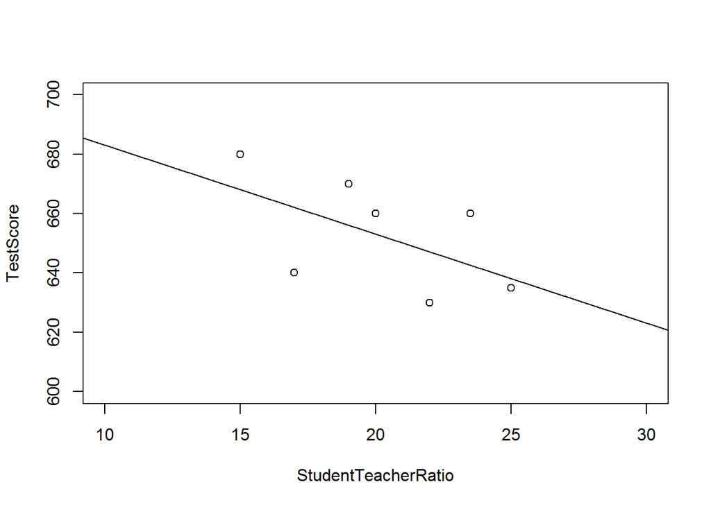

```r
plot(TestScore ~ StudentTeacherRatio, data = class_data, ylim = c(600, 700), xlim = c(10,30))
abline(a = 713, b = -3)
```

We find that our line does not touch any of the points and still we argued that it represents the true relationship. The reason for this is the core problem (and also the right to exist) of statistics, randomness. There are almost always effects which cannot be explained in a deterministic fassion and which excaberate the finding of the “truth”.

In order to account for the differences the regression model is extended by an **error term** which covers these random effect. This **error term** generally accounts for all differences between the “true” regression line and the actual observed data. This could next to the pure randomness also be measerment errors or the effect of important but not considered independent variables.

### Key Concept 4.1

### Terminology for the Linear Regression Model with a Single Regressor

The linear regression model is

$$Y_i = \beta_0 + \beta_1 X_1 + u_i$$

where

- the subscript i runs over observations, $i = 1$, …, $n$
- $Y_i$ is the *dependent variable*, the *regressand*, or simply the *left-hand variable*
- $X_i$ is the *independent variable*, the *regressor*, or simply the *left-hand variable*
- $\beta_0 + \beta_1 X$ is *population the regression line* or the *population regression function*
- $\beta_0$ is the *intercept* of the population regression line
- $\beta_1$ is the *slope* of the population regression line
- $u_i$ is the *error term*

## 4.2 Estimating the Coefficients of the Linear Regression Model

In practical situations the intercept $\beta_0$ and slope $\beta_1$ of the population regression line are unknown. Therefore, we must use data to estimate the two unknown parameters. We will demonstrate how to do that on a real data example. We want to relate test scores to class sizes in 420 California school restricts. The test score is the districtwide average of reading and math scores for fifth graders. Class size is measured as the number of students divided by the number of teachers (student-teacher ratio). The California Shool dataset is available in the `AER` package. After installing the package with `install.packages(AER)` and attaching it with `Library()` the dataset can be loaded using the `data()` function.

```r
library(AER)                                                    # contains the dataset
data(CASchools)
```

With `head()` we get a first overview over our data. This function shows only the first 6 rows of the dataset which prevents an overcrowded console output.

```r
head(CASchools)
```

```
##   district                          school  county grades students
## 1    75119              Sunol Glen Unified Alameda  KK-08      195
## 2    61499            Manzanita Elementary   Butte  KK-08      240
## 3    61549     Thermalito Union Elementary   Butte  KK-08     1550
## 4    61457 Golden Feather Union Elementary   Butte  KK-08      243
## 5    61523        Palermo Union Elementary   Butte  KK-08     1335
## 6    62042         Burrel Union Elementary  Fresno  KK-08      137
##   teachers calworks   lunch computer expenditure    income   english  read
## 1    10.90   0.5102  2.0408       67    6384.911 22.690001  0.000000 691.6
## 2    11.15  15.4167 47.9167      101    5099.381  9.824000  4.583333 660.5
## 3    82.90  55.0323 76.3226      169    5501.955  8.978000 30.000002 636.3
## 4    14.00  36.4754 77.0492       85    7101.831  8.978000  0.000000 651.9
## 5    71.50  33.1086 78.4270      171    5235.988  9.080333 13.857677 641.8
## 6     6.40  12.3188 86.9565       25    5580.147 10.415000 12.408759 605.7
##    math
## 1 690.0
## 2 661.9
## 3 650.9
## 4 643.5
## 5 639.9
## 6 605.4
```

We find that the dataset consists of plenty variables but the two we are intersted in (average test scores and student-teacher ratio) are not included. However, it is easily possible to calculate both from the existing data.

```r
CASchools$tsratio  <- CASchools$students/CASchools$teachers     # teacher-student-ratio
CASchools$score    <- (CASchools$read + CASchools$math)/2       # average test-score
```

```r
avg_tsratio   <- mean(CASchools$tsratio)
avg_score     <- mean(CASchools$score)
sd_tsratio    <- sd(CASchools$tsratio)
sd_tsratio    <- sd(CASchools$score)
quantiles     <- c(0.10, 0.25, 0.4, 0.5, 0.6, 0.75, 0.9)
quant_tsratio <- quantile(CASchools$tsratio, quantiles)
quant_score   <- quantile(CASchools$score, quantiles)

#Gather everything in a data frame
DistributionSummary <- data.frame(Average           = c(avg_tsratio, avg_tsratio),
                                  StandardDeviation = c(sd_tsratio, sd_tsratio),
                                  quantile          = rbind(quant_tsratio, quant_score)
                                  )
DistributionSummary
```

```
##                Average StandardDeviation quantile.10. quantile.25.
## quant_tsratio 19.64043          19.05335      17.3486     18.58236
## quant_score   19.64043          19.05335     630.3950    640.05000
##               quantile.40. quantile.50. quantile.60. quantile.75.
## quant_tsratio     19.26618     19.72321      20.0783     20.87181
## quant_score      649.06999    654.45000     659.4000    666.66249
##               quantile.90.
## quant_tsratio     21.86741
## quant_score      678.85999
```

Figure 4.2 shows a scatterplot of all observations. We see that the points are scatterd strongly and the correlation is with $-0.23$ rather weak. The task we are facing now is to find the line which fit best to this data.

```r
cor(CASchools$tsratio, CASchools$score)
```

```
## [1] -0.2263627
```

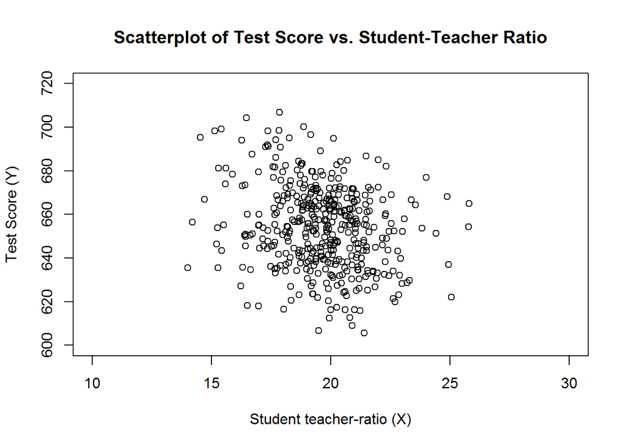

```r
plot(score ~ tsratio,
     data = CASchools,
     main = "Scatterplot of Test Score vs. Student-Teacher Ratio",
     xlab = "Student teacher-ratio (X)",
     ylab = "Test Score (Y)",
     xlim = c(10,30),
     ylim = c(600, 720))
```

## The Ordinary Least Squares Estimator (OLS)

The OLS estimator chooses the regression coefficients so that the estimated regression line is as close as possible to the observed data. Closeness is measured by the sum of the squared mistakes made in predicting $Y$ given $X$. Let $b_0$ and $b_1$ be some estimator of $\beta_0$ and $\beta_1$ then the total squared estimation mistakes can be expressed as:

$$\sum^n_{i = 1} (Y_i - b_0 - b_1 X_i)^2$$
.

The OLS Estimator is the pair of estimators for intercept and slope which minimizes this expression.

### Key Concept 4.2

### The OLS Estimator, Predicted Values, and Residuals

The OLS estimators of the slope $\beta_1$ and the intercept $\beta_0$ are

\begin{align} \hat{\beta_1} & = \frac{\sum_{i = 1}^n (X_i - \bar{X})(Y_i - \bar{Y})} { \sum_{i=1}^n (X_i - \bar{X})^2} = \frac{s_{xy}} {s^2_X} \\ \\ \hat{\beta_0} & = \bar{Y} - \hat{\beta_1} \bar{X} \end{align}

The OLS predicted values $\hat{Y_i}$ and residuals $\hat{u_i}$ are

\begin{align} \hat{Y_i} & = \hat{\beta_0} + \hat{\beta_1}X_i\\ \\ \\ \hat{u_i} & = Y_i - \hat{Y_i} \end{align} The estimated intercept $\left(\hat{\beta_0}\right)$, slope $\left(\hat{\beta_1}\right)$, and residuals $\left(\hat{u_i}\right)$ are computed from a sample of n observations of $X_i$ and $Y_i$, $i$, $...$, $n$. These are estimates of the unkown true population intercept $\left(\beta_0 \right)$, slope $\left(\beta_1\right)$, and error term $(u_i)$.

OLS is one of the most widely-used estimation techniques. Hence R, as a statistical programming language, already contains a built-in function called `lm` (**l**inear **m**odel) which can be used to carry out regression analyses. The first argument of the function is the formula with the basic syntax `y ~ x` where `y` is the dependent and `x` the explanatory variable. The argument `data` specifies the dataset to be used in the regression. We now revisit the example from the book where the relationship between students‘ test scores and the student-teacher ratio is analyzed. The following code uses `lm` to replicate equation $(4.11)$.

```r
linear_model <- lm(score ~ tsratio, data = CASchools)
linear_model
```

```
##
## Call:
## lm(formula = score ~ tsratio, data = CASchools)
##
## Coefficients:
## (Intercept)      tsratio
##      698.93        -2.28
```

# 4.5 The Sampling Distribution of the OLS Estimator

Because the OLS estimators $\hat{\beta_0}$ and $\hat{\beta_1}$ are computed from a randomly drawn sample, the estimators themselves are random variables with a probability distribution -the sampling distribution- that describes the values they could take over different random samples. Although the sampling distribution of $\hat{\beta_0}$ and $\hat{\beta_1}$ can be complicated when the sample size is small, it is possible to make certain statements about is that hold for all n. In particular
$$E(\hat{\beta_0}) = \beta_0 \text{ and } E(\hat{\beta_1}) = \beta_1,$$
that is, $\hat{\beta_0}$ and $\hat{\beta_1}$ are unbiased estimators of $\beta_0$ and $\beta_1$. If the sample is sufficiently large, by the central limit theorem zje sampling distribiution of the estimators is well approximated by the bivariate normal distribution. This implies that the marginal distributions are normal in large samples.

### Key Concept 4.4

### Large Sample Distribution of $\hat{\beta_0}$ and $\hat{\beta_1}$

If the least square saaumption in Key Concept 4.3 hold, then in large-samples $\hat{\beta_0}$ and $\hat{\beta_1}$ have a jointly normal sampling distribution. The large-sample normal distribution of $\hat{\beta_1}$ is $N(\beta_1, \sigma^2_\hat{\beta_1})$, where the variance of the distribution, $\sigma^2_\hat{\beta_1}$, is

$$\sigma^2_\hat{\beta_1} = \frac{1}{n} \frac{var \left[ \left(X_i - \mu_X \right) u_i \right]} {\left[ var \left(X_i \right) \right]^2}$$

The large-sample normal distribution of $\hat{\beta_0}$ is $N(\beta_0, \sigma^2_\hat{\beta_0})$, where
$$\sigma^2_\hat{\beta_0} = \frac{1}{n} \frac{var \left( H_i u_i \right)}{ \left[ E \left(H_i^2 \right) \right]^2 }\text{, where } H_i = 1 - \left[ \frac{\mu_X} {E \left( X_1^2\right)} \right] X_i.$$

```r
#Population Regression
pop_n      <- 1000
x          <- runif(pop_n, min = 0, max = 20)
u          <- rnorm(pop_n, sd = 10)
y          <- -2 + 3.5*x + u
population <- data.frame(x, y)



n <- 100 # sample size
sigma_b1 <- var( ( x - mean(x) ) * u ) / (100 * var(x)^2)
H_i      <- 1 - mean(x) / mean(x^2) * x
sigma_b0 <- var(H_i * u) / (n * mean(H_i^2)^2 )

#Estimation
number_of_estimations <- 500


fit <- matrix(ncol = 2, nrow = number_of_estimations)
for (i in 1:number_of_estimations){
 random_sample  <- population[ sample(1:pop_n, n), ]
 fit[i, ]       <- lm(y ~ x, data = random_sample)$coefficients
}

var(fit[ ,1])
```

```
## [1] 3.757158
```

[figure not shown]

```r
hist(fit[ ,1], main = bquote(The ~ distribution  ~ of ~ 500 ~ beta[1] ~ estimates))
```

```r
var(fit[ ,2])
```

```
## [1] 0.02845974
```

[figure not shown]

```r
hist(fit[ ,2], , main = bquote(The ~ distribution  ~ of ~ 500 ~ beta[2] ~ estimates))
```